# Gênero faz diferença?

uma análise das atitudes das eleitoras brasileiras

Larissa Martins Marques

Abstract

Este trabalho se refere ao gap de gênero nas atitudes políticas no Brasil no ano de 2018. Um conjunto diferente de padrões de socialização experimentados por homens e mulheres podem influenciar de forma diferenciada os valores centrais, as orientações políticas e o comportamento. Diante disto, um fator individual, como o sexo, impacta as atitudes políticas no Brasil? Se sim, em quais dimensões? O objetivo do trabalho é averiguar como uma mesma atitude política pode se manifestar de diferentes maneiras a partir do gênero. Para tanto, é desenvolvido testes de deferenças de médias de dois ou mais grupos. Os dados para a análise são do projeto A cara da democracia. Foram selecionadas perguntas que permitam operacionalizar atitudes políticas como o interesse por política e ideologia. Os resultados indicam que apenas as médias de interesse por política apresentaram diferença significante entras mulheres e os homens. Além disso, mulheres de alta escolaridade possuem o mesmo interesse por política do que os homens.

```r
tema <- ggthemes::theme_fivethirtyeight() +
  theme(legend.title = element_text(family = "Times New Roman"),
        legend.position = "bottom",
        title = element_text(size = 10),
        axis.title.y = element_text(size = 14, family = "Times New Roman"),
        axis.text.y = element_text(size = 20, family = "Times New Roman"),
        axis.text.x = element_text(size = 20, family = "Times New Roman"),
        axis.title.x = element_text(size = 20,family = "Times New Roman"),
        legend.text = element_text(size = 30, family = "Times New Roman"),
        plot.caption = element_text(hjust = 0, size = 24, family = "Times New Roman" ),
        panel.background = element_rect(fill = "white", colour = "white", color = "white"),
        plot.background = element_rect(fill = "white", colour = "white", color = "white"),
        legend.background = element_rect(fill = "white"),
        panel.grid.major.x = element_line(colour = "#eceff2", size = 0.8),
        panel.grid.major.y = element_line(colour = "#eceff2", size = 0.8),
        legend.key = element_rect(fill = "white", color = "white"),
        strip.background = element_rect(fill = "white", colour = "white"),
        strip.text = element_text(size = 29, colour = "black", face = "bold", family = "Times New Roman"))

ggplot2::theme_set(tema)
```

# 1 Introdução

A corrente teórica que este relatório se vincula é aquela que se debruça a investigar como a vida social e os diferentes papéis atribuídos às mulheres e homens podem produzir diferenças e semelhanças nas atitudes e comportamentos políticos. Busca-se analisar a relação entre o gênero, escolaridade e as atitudes políticas femininas. O objetivo, então, é examinar a relação entre o gênero e atitudes políticas, como a ideologia e o interesse por política. Deste modo, o fator explicativo do relatório está centrado no nível individual.

A análise toma como problema a estrutura tradicional de organização social e familiar que imputam às mulheres diferentes relações e funções sociais. Seria então, o gênero um fator determinante para a condução de comportamentos e atitudes políticas. Com isso, um conjunto distinto de padrões de socialização experimentados por homens e mulheres poderia influenciar de forma diferenciada os valores centrais, as orientações políticas e o comportamento (Biroli 2016). O intuito deste trabalho é refletir sobre a socialização feminina e as atitudes políticas de gênero.

O ano de 2018 protagonizou o desenvolvimento de uma nítida clivagem de gênero quanto a escolha do futuro presidente. Ao analisar as eleições presidenciais passadas, mulheres pela primeira vez manifestaram uma ampla rejeição a um candidato específico comparado com os homens (Nicolau 2020). Essas diferenças de gênero não são encontradas apenas na escolha do representante, como também nos percentuais de presença feminina nos parlamentos, nas taxas de participação, na filiação partidária, na probabilidade de concorrer a cargos eletivos, assim como em valores e atitudes políticas.

As origens e a magnitude do gap de gênero são motivos de agendas de pesquisa que datam maior aparição a partir dos anos 80. Estes trabalhos utilizam diferentes eixos argumentativos para elucidar as causas das distâncias atitudinais e comportamentais entre mulheres e homens. Embora sejam diversas as possibilidades de se estudar este fenômeno, para analisar as distâncias de gênero nas atitudes políticas no presente trabalho, foram abordadas duas teorias que tratam a composição dos seres humanos de acordo com o seu gênero. A primeira perspectiva teórica enfatiza as diferenças na socialização política de homens e mulheres que funcionam como moldadores de opiniões, atitudes e comportamentos políticos futuros dos indivíduos. A segunda aborda as mudanças decorrentes da inserção no mercado de trabalho remunerado na cultura política feminina.

A tese psicológica destaca a importância da socialização na infância. Esta perspectiva interpreta o surgimento das diferenças de gênero como produto dos contextos de socialização que homens e mulheres experimentaram na infância e na adolescência. A gama de experimentações sociais, vinculadas às experiências de desigualdade e interconexão inerentes à relação entre os pais e filhos, são acumuladas até a vida adulta, onde conduzem a um conjunto de valores e opiniões que foram estruturados durante a infância (Gilligan 1936).

Não obstante, os efeitos provenientes do processo socialização na infância sofrem mediação da estrutura de papéis sociais atribuídos a homens e mulheres. Uma das chaves analíticas da teoria dos papéis para explicar as lacunas de gênero nas atitudes políticas se baseia nos papéis sociais de homens e mulheres (Eagly and Diekman 2006). Diekman and Schneider (2010) em estudo que investiga a relação de papéis específicos dos indivíduos e atitudes políticas, argumentam que o conjunto de atitudes e comportamentos de uma pessoa funda-se a partir das expectativas sociais e normas que são geradas de acordo com o gênero, ou seja, existem papéis que são socialmente esperados e vinculados aos indivíduos de acordo com seu gênero. Para as autoras, estas expectativas pré-definidas levam os indivíduos a ficarem expostos a certas experiências próprias ligadas aos homens e as mulheres. Uma vez internalizadas pelos indivíduos, tais normas e expectativas são aplicadas em situações cotidianas e estão relacionadas a uma diversidade de preferências sociais capazes de diferenciar as atitudes de grupos.

Com isso, as lacunas de gênero em atitudes políticas são construídas em conformidade com os papéis sociais atribuídos aos homens e as mulheres. Nesta estrutura de papéis, para as mulheres, presume-se que estejam relacionados os aspectos voltados à esfera privada como a passividade e reprodução (Dantas-Berger e Giffin, 2005) assim como as tarefas do cuidado doméstico e familiar (Biroli, 2016; Diekman e Schneider, 2010). Enquanto que para os homens, é reservado às funções inerentes à esfera pública e o papel de provedor econômico (Dantas-Berger and Giffin 2005). Com base nestas funções, é possível enxergar o gênero como um atributo individual capaz de predizer comportamentos e atitudes a serem materializadas em sociedade.

Ambas as abordagens teóricas levam a esperar uma divergência entre os indivíduos em suas opiniões em detrimento da forma como se definem as relações de gênero ainda na infância e baseada em papéis. O gênero, funciona, então, como um atributo individual capaz de predizer comportamentos e atitudes a serem materializadas em sociedade. Deste modo, é razoável inferir que papéis e os estereótipos de gênero tenham a possibilidade de produzir atitudes políticas diferenciadas.

Após realizar uma breve exposição dos diferentes aspectos que o curso da vida de homens e mulheres podem tomar, o objetivo deste trabalho consiste em investigar nas dimensões de ideologia e interesse por política se é possível observar as lacunas de gênero.

Além dessa introdução o relatório conta com seções de metodologia, análises dos dados e considerações finais.

# 2 Metodologia

Os dados provêm do projeto [“A cara da democracia”](https://www.institutodademocracia.org/a-cara-da-democracia), survey de circulação nacional que possui como objetivo capturar momentaneamente o que o brasileiro pensa sobre democracia e como constitui seu sistema de valores, crenças e atitudes políticas. O relatório compreende como recorte temporal o ano de 2018, primeiro ano em que se produziu dados para o Brasil.

- homens (todas as escolaridades)

## 2.1 Teste de médias e medianas

O teste selecionado para desenvolver a análise foi o Teste T. Os pressupostos deste teste exigem normalidade na distribuição dos dados e homogeneidade das variâncias dos grupos. Quando esses pressupotos não foram ser atendidos, foi utilizado o pacote estatístico [infer](https://infer.netlify.app/) que possui tratamento dos dados via Bootstrap e possibilidade de se realizar o cálculo para variâncias não homogêneas.

Para a análise das atitudes intra grupos, foi adotado o teste de Kruskal-Wallis.

## 2.2 As variáveis

- **Independente**: Gênero.
- **Dependentes**: Ideologia; Interesse por política.

## 2.3 Hipóteses

**As hipóteses da primeira dimensão são:**

H1: mulheres divergem, em média, da ideologia dos homens;

**As hipóteses da segunda dimensão são:**

H1: mulheres manifestam menor interesse por política do que os homens;

H1: mulheres com alta escolaridade vão manifestar maior interesse por política do que mulheres com baixa escolaridade;

H1: mulheres com alta escolaridade possuem menor interesse por política do que os homens.

# 3 Análises

## 3.1 Ideologia

Essa dimensão mensura a ideologia do entrevistado a partir de um autoposicionamento ideológico em uma escala númerica contínua de 1 a 10. A localização 1 indica extrema esquerda enquanto a posição 10 indica a extrema direita.

O que se pretende responder é: o gênero faz diferença na hora de se posicionar na escala ideológica de esquerda e direita?

### 3.1.1 O banco

A seguir algumas informações sobre os dados de gênero e ideologia

```r
tabela_1 <- data_2018_a %>%
  filter(ed <=10) %>%
  select(ed, sexo) %>%
  group_by(sexo, ed) %>%
  summarise(Total_casos_sexo_ideologia = n()) %>%
  ungroup() %>%
  mutate(N = sum(Total_casos_sexo_ideologia),
         sexo = case_when(sexo == 1 ~ "Homem",
                          sexo == 2 ~ "Mulher"))
tabela_1 %>%
  kbl() %>%
  kable_material(c("striped")) %>%
  scroll_box(width = "1000px", height = "300px")
```

| sexo | ed | Total_casos_sexo_ideologia | N |
| --- | --- | --- | --- |
| Homem | 1 | 86 | 1534 |
| Homem | 2 | 45 | 1534 |
| Homem | 3 | 45 | 1534 |
| Homem | 4 | 55 | 1534 |
| Homem | 5 | 227 | 1534 |
| Homem | 6 | 68 | 1534 |
| Homem | 7 | 46 | 1534 |
| Homem | 8 | 77 | 1534 |
| Homem | 9 | 60 | 1534 |
| Homem | 10 | 103 | 1534 |
| Mulher | 1 | 74 | 1534 |
| Mulher | 2 | 38 | 1534 |
| Mulher | 3 | 32 | 1534 |
| Mulher | 4 | 40 | 1534 |
| Mulher | 5 | 196 | 1534 |
| Mulher | 6 | 83 | 1534 |
| Mulher | 7 | 55 | 1534 |
| Mulher | 8 | 42 | 1534 |
| Mulher | 9 | 42 | 1534 |
| Mulher | 10 | 120 | 1534 |

### 3.1.2 A distribuição

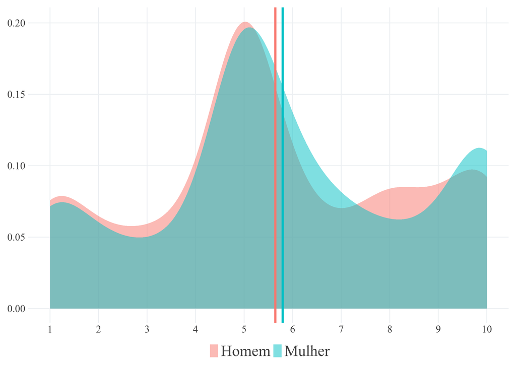

```r
# visualizar a distribuicão da ideologia de acordo com o gênero

ideo_data_2018_a <- data_2018_a %>%
  drop_na(c(ed, sexo)) %>% # retira os NA
  filter(ed<=10) # filtra apenas os valores de interesse
  #
ideo_data_2018_a %>%
  mutate(sexo = case_when(sexo == 1 ~ "Homem",
                          sexo == 2 ~ "Mulher")) %>%  # altera rótulo das variáveis
    ggplot(aes(x=ed, fill = as_factor(sexo), col = as_factor(sexo), group = as_factor(sexo)))+
  geom_density(color=NA, alpha = 0.5)+
  geom_vline(data=. %>% group_by(sexo) %>% summarise(media=mean(ed,na.rm = T)),
             size=2, aes(xintercept=media,color=sexo), show.legend = F) +
  scale_x_continuous(breaks = c(1:10))+
  tema+
  labs(x= NULL, y=NULL, fill = NULL, col = NULL, group = NULL)
```

### 3.1.3 Teste de normalidade

Uma segunda alternativa de se verificar a normalidade dos dados é com o teste estatístico de normalidade

No programa R é feita pela função “shapiro_test()”

H1 - a distribuição dos dados é diferente da normal

```r
ideo_data_2018_a %>% shapiro_test(ed, sexo)
```

```
## # A tibble: 2 × 3
##   variable statistic        p
##   <chr>        <dbl>    <dbl>
## 1 ed           0.929 2.61e-26
## 2 sexo         0.635 4.42e-49
```

### 3.1.4 Homogeneidade das variâncias

H0: Os grupos possuem a mesma variância

H1: As variâncias dos grupos não são homogenas -> p<= 0.05

```r
# Teste feito com o pacote car

leveneTest(
  y = ideo_data_2018_a$ed,
  group = ideo_data_2018_a$sexo
)
```

```
## Levene's Test for Homogeneity of Variance (center = median)
##         Df F value Pr(>F)
## group    1  0.1616 0.6877
##       1532
```

A partir da análise do p-valor, considera-se que as variâncias dos grupos são homogêneas.

### 3.1.5 Test-T

```r
ideo_data_2018_a %>%
infer::t_test(formula = ed ~ sexo, var.equal = TRUE)
```

```
## # A tibble: 1 × 7
##   statistic  t_df p_value alternative estimate lower_ci upper_ci
##       <dbl> <dbl>   <dbl> <chr>          <dbl>    <dbl>    <dbl>
## 1     -1.06  1532   0.287 two.sided     -0.151   -0.429    0.127
```

A partir do resultado do Test T é possível dizer que se aceita H0. Dito de outra maneira, o gênero não fez diferença no posicionamento ideológico no ano de 2018.

### 3.1.6 Graficando

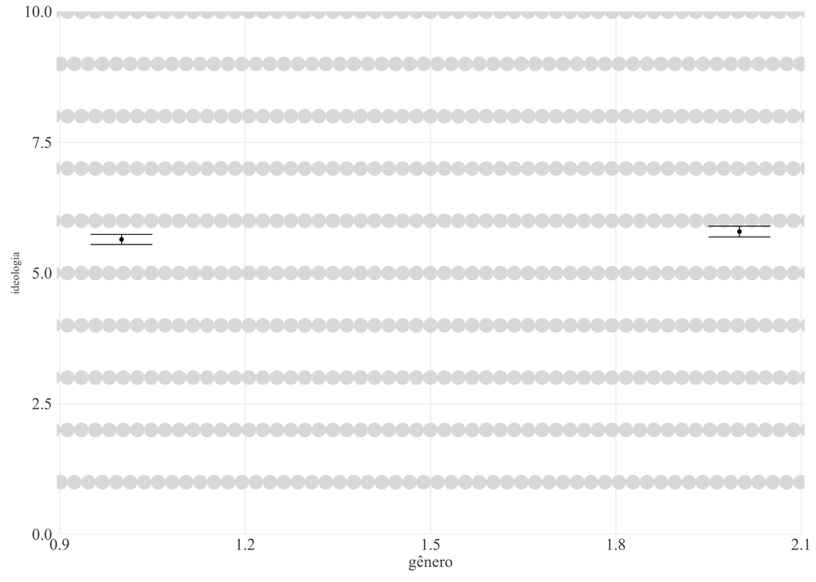

```r
# graficando as médias de

ggplot(data = ideo_data_2018_a %>%
         drop_na(ed),
       mapping = aes(y = ed, x = sexo)) +
  geom_dotplot(binaxis = "y", stackdir = "center",
               fill="#D8D8D8", color="#D8D8D8", dotsize = 0.8) +
  geom_point(stat = "summary", fun = "mean", size = 2) +
  geom_errorbar(stat = "summary", fun.data = "mean_se", width = 0.1) +
  labs(y="ideologia", x= "gênero") +
  scale_y_continuous(limits=c(0,10), expand = c(0,0))
```

### 3.1.7 Diferenças internas as mulheres de acordo com a escolaridade

Esta segunda etapa possui o objetivo de analisar comparativamente como as mulheres se diferenciam ou se assemelham de acordo com a escolaridade. Além disso, investiga se as mulheres dos diferentes graus de escolaridade divergem dos homens.

Neste momento, a questão que se procura responder é se as mulheres são mais diferentes entre elas ou entre elas e os homens?

```r
# criar uma variável com os três grupos

data_2018_escolaridade <- data_2018_a %>%
  select(sexo, esc, ed) %>%
  filter(sexo == c(1,2),
         ed<= 10,
         esc <= 10) %>%
  drop_na() %>%
  mutate(grupo_escolaridade = ifelse(sexo == 2 & esc %in% c(1:3), "Mulher baixa escolaridade",
                                     ifelse(sexo == 2 & esc %in% c(4:7), "Mulher média escolaridade",
                                            ifelse(sexo == 2 & esc %in% c(8:10), "Mulher alta escolaridade",
                                                   ifelse(sexo == 1 & esc %in% c(1:10), "Homem todas as escolaridades", sexo)))))


# testar os pressupostos - normalidade

data_2018_escolaridade %>%
  group_by(grupo_escolaridade) %>%
  shapiro_test(ed)  # p < 0.05 = distribuicão dos dados não normais
```

```
## # A tibble: 4 × 4
##   grupo_escolaridade           variable statistic        p
##   <chr>                        <chr>        <dbl>    <dbl>
## 1 Homem todas as escolaridades ed           0.931 4.27e-13
## 2 Mulher alta escolaridade     ed           0.906 3.36e- 5
## 3 Mulher baixa escolaridade    ed           0.899 1.06e- 5
## 4 Mulher média escolaridade    ed           0.930 1.11e- 8
```

```r
# testar os pressupostos - homogeneidade das variâncias

leveneTest(ed ~ grupo_escolaridade, data_2018_escolaridade) # p > 0.05 = variancias são homogeneas
```

```
## Levene's Test for Homogeneity of Variance (center = median)
##        Df F value Pr(>F)
## group   3  1.3707 0.2505
##       792
```

```r
# preciso usar o teste para dados não paramétricos - Kruskal - Wallis
```

### 3.1.8 Kruskal-Wallis

A escolha deste teste acontece pois os dados não atendem aos pressupostos da ANOVA.

```r
kruskal.test(ed ~ grupo_escolaridade, data = data_2018_escolaridade)
```

```
##
##  Kruskal-Wallis rank sum test
##
## data:  ed by grupo_escolaridade
## Kruskal-Wallis chi-squared = 2.4595, df = 3, p-value = 0.4826
```

A analise do teste de Kruskal-Wallis permite concluir que as medianas dos grupos são iguais. Ou seja, não há diferenças no posicionamento ideológico de mulheres e homens significantes.

## 3.2 Interesse por política

Essa dimensão mensura o grau de interesse por política do entrevistado.

A pergunta é feita da seguinte maneira:

Quanto o(a) sr(a) se interessa por política? O(a) sr(a) diria que é:

1. Muito interessado,
2. Interessado,
3. Pouco interessado, ou
4. Nada Interessado.

No presente trabalho, para fins metodológicos as categorias (1-4) são tratas como númericas.

### 3.2.1 O banco

A seguir algumas informações sobre os dados de gênero e interesse por política

```r
tabela_2 <- data_2018_a %>%
  filter(interesse <=4) %>%
  select(interesse, sexo) %>%
  group_by(sexo, interesse) %>%
  summarise(Total_casos_sexo_interesse = n()) %>%
  ungroup() %>%
  mutate(N = sum(Total_casos_sexo_interesse),
         sexo = case_when(sexo == 1 ~ "Homem",
                          sexo == 2 ~ "Mulher"),
          interesse= case_when(interesse== 1 ~ "Muito interessado",
                                                 interesse== 2 ~ "Interessado",
                                                 interesse== 3 ~ "Pouco interessado",
                                                 interesse== 4 ~ "Nada Interessado"))
tabela_2 %>%
  kbl() %>%
  kable_material(c("striped")) %>%
  scroll_box(width = "1000px", height = "300px")
```

| sexo | interesse | Total_casos_sexo_interesse | N |
| --- | --- | --- | --- |
| Homem | Muito interessado | 88 | 2459 |
| Homem | Interessado | 185 | 2459 |
| Homem | Pouco interessado | 515 | 2459 |
| Homem | Nada Interessado | 396 | 2459 |
| Mulher | Muito interessado | 46 | 2459 |
| Mulher | Interessado | 113 | 2459 |
| Mulher | Pouco interessado | 493 | 2459 |
| Mulher | Nada Interessado | 623 | 2459 |

### 3.2.2 A distribuição

[figure not shown]

```r
data_2018_interesse <- data_2018_a %>%
  drop_na(c(interesse, sexo)) %>% # retira os NA
  filter(interesse<=4) # filtra apenas os valores de interesse


data_2018_interesse %>%
  mutate(sexo = case_when(sexo == 1 ~ "Homem",
                          sexo == 2 ~ "Mulher")) %>% # altera rótulo das variáveis
    ggplot(aes(x=interesse, fill = as_factor(sexo), col = as_factor(sexo), group = as_factor(sexo)))+
  geom_density(color=NA, alpha = 0.5)+
  geom_vline(data=. %>% group_by(sexo) %>% summarise(media=mean(interesse,na.rm = T)),
             size=2, aes(xintercept=media,color=sexo), show.legend = F) +
  scale_x_continuous(breaks = c(1:10))+
  tema+
  labs(x= NULL, y=NULL, fill = NULL, col = NULL, group = NULL)
```

### 3.2.3 Teste de normalidade

```r
data_2018_interesse %>%
  shapiro_test(interesse,sexo)
```

```
## # A tibble: 2 × 3
##   variable  statistic        p
##   <chr>         <dbl>    <dbl>
## 1 interesse     0.800 5.88e-48
## 2 sexo          0.636 3.93e-58
```

O shapiro teste reportou a não normalidade da distribuição dos dados. Logo, é preciso a adequar o Teste T.

### 3.2.4 Homogeneidade das variâncias

```r
leveneTest(y = data_2018_interesse$interesse,
  group = data_2018_interesse$sexo)
```

```
## Levene's Test for Homogeneity of Variance (center = median)
##         Df F value Pr(>F)
## group    1  0.1834 0.6685
##       2457
```

As variâncias são homogeneas.

### 3.2.5 Teste T

```r
data_2018_interesse %>% infer::t_test(interesse ~ sexo)
```

```
## # A tibble: 1 × 7
##   statistic  t_df  p_value alternative estimate lower_ci upper_ci
##       <dbl> <dbl>    <dbl> <chr>          <dbl>    <dbl>    <dbl>
## 1     -8.81 2365. 2.46e-18 two.sided     -0.298   -0.365   -0.232
```

O Teste T apresenta uma diferença significante entre as médias dos grupos. Nesse caso, a média de interesse por política das mulheres é diferente da média de interesse por política dos homens.

Com esses resultados, torna-se interessante visualizar a distribuição das diferenças das médias. Gráfico que pode ser encontrado ao final dessa seção.

### 3.2.6 Graficando

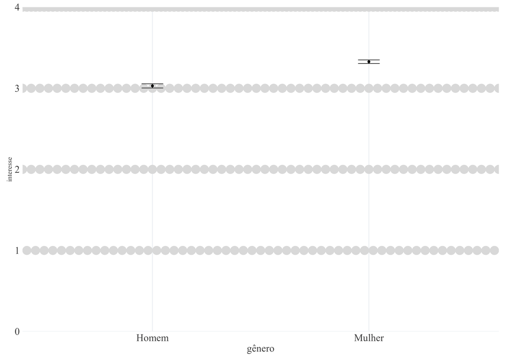

```r
ggplot(data = data_2018_interesse %>%
         mutate(sexo = case_when(sexo == 1 ~ "Homem",
                          sexo == 2 ~ "Mulher")) %>%
         drop_na(interesse),
       mapping = aes(y = interesse, x = sexo)) +
  geom_dotplot(binaxis = "y", stackdir = "center",
               fill="#D8D8D8", color="#D8D8D8", dotsize = 0.8) +
  geom_point(stat = "summary", fun = "mean", size = 2) +
  geom_errorbar(stat = "summary", fun.data = "mean_se", width = 0.1) +
  labs(y="interesse", x= "gênero") +
  scale_y_continuous(limits=c(0,4), expand = c(0,0))
```

### 3.2.7 Diferenças internas as mulheres de acordo com a escolaridade

```r
# criar uma variável com os três grupos

data_2018_escolaridade_interesse <- data_2018_a %>%
  select(sexo, esc, interesse) %>%
  filter(sexo == c(1,2),
         interesse <= 4,
         esc <= 10) %>%
  drop_na() %>%
  mutate(grupo_escolaridade = ifelse(sexo == 2 & esc %in% c(1:3), "Mulher baixa escolaridade",
                                     ifelse(sexo == 2 & esc %in% c(4:7), "Mulher média escolaridade",
                                            ifelse(sexo == 2 & esc %in% c(8:10), "Mulher alta escolaridade",
                                                   ifelse(sexo == 1 & esc %in% c(1:10), "Homem todas as escolaridades", sexo)))))


# testar os pressupostos - normalidade

data_2018_escolaridade_interesse %>%
  group_by(grupo_escolaridade) %>%
  shapiro_test(interesse)  # p > 0.05 = distribuicão dos dados são normais
```

```
## # A tibble: 4 × 4
##   grupo_escolaridade           variable  statistic        p
##   <chr>                        <chr>         <dbl>    <dbl>
## 1 Homem todas as escolaridades interesse     0.840 4.16e-24
## 2 Mulher alta escolaridade     interesse     0.828 8.24e-10
## 3 Mulher baixa escolaridade    interesse     0.711 2.32e-16
## 4 Mulher média escolaridade    interesse     0.746 8.91e-24
```

```r
# testar os pressupostos - homogeneidade das variâncias

leveneTest(interesse ~ grupo_escolaridade,
           data_2018_escolaridade_interesse,
           center = mean) # p > 0.05 = variancias são homogeneas
```

```
## Levene's Test for Homogeneity of Variance (center = mean)
##         Df F value  Pr(>F)
## group    3  2.8617 0.03576 *
##       1246
## ---
## Signif. codes:  0 '***' 0.001 '**' 0.01 '*' 0.05 '.' 0.1 ' ' 1
```

```r
# preciso usar o teste para dados não paramétricos - Kruskal - Wallis
```

### 3.2.8 Teste de Kruskal Wallis

Neste momento se investiga o intersse por política entre as mulheres com diferentes níveis de escolaridade e com os homens.

```r
kruskal.test(interesse ~ grupo_escolaridade,
             data = data_2018_escolaridade_interesse)
```

```
##
##  Kruskal-Wallis rank sum test
##
## data:  interesse by grupo_escolaridade
## Kruskal-Wallis chi-squared = 72.742, df = 3, p-value = 1.104e-15
```

O teste reporta que pelo menos uma das medianas dos grupos são diferentes. Porém, ainda não é possível saber qual dos grupos que são diferentes. Por este motivo, foi feito o teste post hoc de Dunn.

### 3.2.9 Post hoc teste Dunn

Este teste foi realizado com o ajuste de bonferroni.

```r
dunn_test(interesse ~ grupo_escolaridade, data = data_2018_escolaridade_interesse,
          p.adjust.method = "bonferroni")
```

```
## # A tibble: 6 × 9
##   .y.       group1   group2    n1    n2 statistic        p    p.adj p.adj.signif
## * <chr>     <chr>    <chr>  <int> <int>     <dbl>    <dbl>    <dbl> <chr>
## 1 interesse Homem t… Mulhe…   601   107   -0.0136 9.89e- 1 1   e+ 0 ns
## 2 interesse Homem t… Mulhe…   601   160    6.61   3.81e-11 2.29e-10 ****
## 3 interesse Homem t… Mulhe…   601   382    6.58   4.68e-11 2.81e-10 ****
## 4 interesse Mulher … Mulhe…   107   160    4.72   2.35e- 6 1.41e- 5 ****
## 5 interesse Mulher … Mulhe…   107   382    3.95   7.82e- 5 4.69e- 4 ***
## 6 interesse Mulher … Mulhe…   160   382   -1.67   9.44e- 2 5.66e- 1 ns
```

Os resultados deste testes foram interpretados a partir do p-valor ajustado que só não reportou diferença estatística significante entre as mulheres de alta escolaridade e os homens e as mulheres de baixa escolaridade e as mulheres de média escolaridade. Esses resultados podem sugerir a escolaridade alta é um atributo individual capaz de aproximar as posições femininas quanto ao interesse por política das posições masculinas.

Além desses testes, também foi desenvolvido um passo no relatório que passou por um tratamento automático de Bootstrap. Para isso foi utilizado as funções do pacote [dabestr](https://cran.r-project.org/web/packages/dabestr/vignettes/using-dabestr.html)

```r
two.group.unpaired <-
  data_2018_escolaridade_interesse %>%
  dabest(grupo_escolaridade, interesse,
         # The idx below passes "Control" as the control group,
         # and "Group1" as the test group. The mean difference
         # will be computed as mean(Group1) - mean(Control1).
         idx = c("Homem todas as escolaridades", "Mulher alta escolaridade",
                 "Mulher baixa escolaridade", "Mulher média escolaridade"),
         paired = FALSE)

two.group.unpaired
```

```
## dabestr (Data Analysis with Bootstrap Estimation in R) v0.3.0
## =============================================================
##
## Good evening!
## The current time is 23:41  on quinta outubro 06, 2022.
##
## Dataset    :  .
## The first five rows are:
##   sexo esc interesse           grupo_escolaridade
## 1    2   4         4    Mulher média escolaridade
## 2    1   4         4 Homem todas as escolaridades
## 3    2   4         4    Mulher média escolaridade
## 4    2   3         4    Mulher baixa escolaridade
## 5    1   4         4 Homem todas as escolaridades
##
## X Variable :  grupo_escolaridade
## Y Variable :  interesse
##
## Effect sizes(s) will be computed for:
##   1. Mulher alta escolaridade minus Homem todas as escolaridades
##   2. Mulher baixa escolaridade minus Homem todas as escolaridades
##   3. Mulher média escolaridade minus Homem todas as escolaridades
```

```r
two.group.unpaired.meandiff <- mean_diff(two.group.unpaired)

two.group.unpaired.meandiff
```

```
## dabestr (Data Analysis with Bootstrap Estimation in R) v0.3.0
## =============================================================
##
## Good evening!
## The current time is 23:41  on quinta outubro 06, 2022.
##
## Dataset    :  .
## X Variable :  grupo_escolaridade
## Y Variable :  interesse
##
## Unpaired mean difference of Mulher alta escolaridade (n = 107) minus Homem todas as escolaridades (n = 601)
##  0.00959 [95CI  -0.186; 0.193]
##
## Unpaired mean difference of Mulher baixa escolaridade (n = 160) minus Homem todas as escolaridades (n = 601)
##  0.528 [95CI  0.405; 0.651]
##
## Unpaired mean difference of Mulher média escolaridade (n = 382) minus Homem todas as escolaridades (n = 601)
##  0.384 [95CI  0.275; 0.492]
##
##
## 5000 bootstrap resamples.
## All confidence intervals are bias-corrected and accelerated.
```

É possível observar que não há alterações significantes quanto aos resultados dos testes mesmo após os tratamentos de normalização dos dados.

A figura abaixo é uma representação gráfica das comparações feitas anteriormente. Nela é apresentado todos os valores observáveis na amostra além de exibir a distribuição das deferenças de médias.

### 3.2.10 Graficando com dabestr

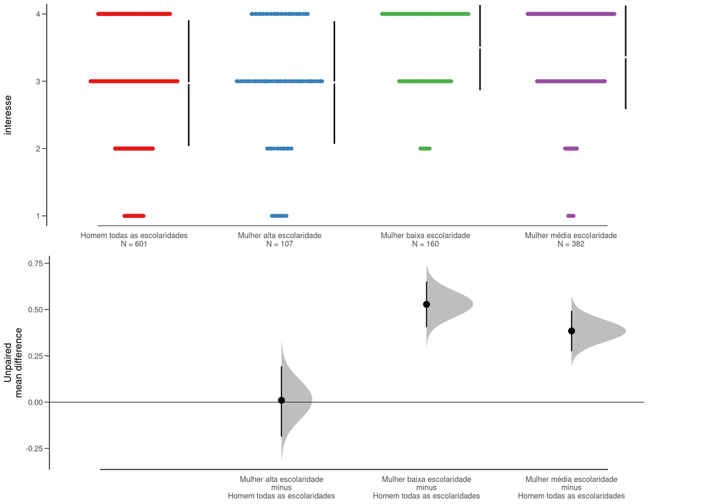

```r
plot(two.group.unpaired.meandiff)
```

# 4 Considerações finais

O presente relatório teve como objetivo analisar como a variável gênero interage com as atitudes políticas. Mais especificamente, as atitudes políticas selecionadas foram a ideologia e o interesse por política. Para a construção do problema de pesquisa o recorte bibliográfico buscou trazer a teoria psicológica e a teoria social como uma alternativa de abordar como as diferentes experimentações dos gêneros em contextos sociais e psicológicos de socialização podem resultar em processos sociais distintos, entre eles, as atitudes políticas.

A hipótse que levou em consideração o efeito entre a ideologia e o gênero não pode ser aceita. Nesse caso, aceitou-se a hipótese nula, ou seja, a igualdade do posicionamento ideológico médio de homens e mulheres. Já as hipóteses correlatas a relação de efeito entre interesse por política gênero foram aceitas na medida em que se observou diferença significante entre os dois grupos analisados. Foi encontrado diferença interna ao grupo das mulheres e diferença significante entre mulheres e homens.

Com estes resultados e com as técnicas estatísticas até aqui empregadas, não é possível atribuir causalidade entre as relações observadas. Com isso, os próximos passos serão destinados a investigar outras relações a partir de análises multivarias e técinas de regressão estatísticas apropridas as variáveis.

# 5 Referências

Biroli, Flávia. 2016. “Divisão Sexual do Trabalho e Democracia.” *Dados* 59 (3): 719–54. https://doi.org/10.1590/00115258201690.

Dantas-Berger, Sônia Maria, and Karen Giffin. 2005. “A Violência Nas Relações de Conjugalidade: Invisibilidade e Banalização Da Violência Sexual?” *Cadernos de Saúde Pública* 21: 417–25.

Diekman, Amanda B., and Monica C. Schneider. 2010. “A social role theory perspective on gender gaps in political attitudes.” *Psychology of Women Quarterly* 34 (4): 486–97. https://doi.org/10.1111/j.1471-6402.2010.01598.x.

Eagly, Alice H, and Amanda B Diekman. 2006. “Examining Gender Gaps in Sociopolitical Attitudes: It’s Not Mars and Venus.” *Feminism & Psychology* 16 (1): 26–34.

Gilligan, Carol. 1936. *In a Different Voice: Psychological Theory and Women’s Development*. Cambridge, Mass.: Harvard University Press.

Nicolau, Jairo. 2020. *O Brasil Dobrou à Direita: Uma Radiografia Da Eleição de Bolsonaro Em 2018*. Vol. 1. Rio de Janeiro: Zahar.

[^1]: Analfabeto ou Nunca frequentou escola / até 3ª serie do ensino fundamental / 4ª.serie do ensino fundamental.
[^2]: até 7ª série do ensino fundamental / 8ª série do ensino fundamental / até 2ª série do ensino médio / 3ª série do ensino médio.
[^3]: técnico após ensino médio / Ensino universitário completo / Pós-graduação ou mais.